# Data 624 HW7

V Patel

2020-11-02

```r
if (!require("fpp2")) install.packages("fpp2")
if (!require("caret")) install.packages("caret")
if (!require("AppliedPredictiveModeling")) install.packages("AppliedPredictiveModeling")
if (!require("naniar")) install.packages("naniar")
if (!require("missForest")) install.packages("missForest")
```

### 6.2 Developing a model to predict permeability (see Sect 1.4) could save significant resources for a pharmaceutical company, while at the same time more rapidly identifying molecules that have a sufficient permeability to become a drug:

#### (a) Start R and use these commands to load the data:

```r
library(AppliedPredictiveModeling)
data(permeability)
head(permeability)
```

```
##   permeability
## 1       12.520
## 2        1.120
## 3       19.405
## 4        1.730
## 5        1.680
## 6        0.510
```

#### (b) The fingerprint predictors indicate the presence or absence of substructures of a molecule and are often sparse meaning that relatively few of the molecules contain each substructure. Filter out the predictors that have low frequencies using the `nearZeroVar` function from the `caret` package. How many predictors are left for modeling?

```r
library(caret)

dim(fingerprints)
```

```
## [1]  165 1107
```

```r
fingerprints_nZ <- fingerprints[, -nearZeroVar(fingerprints)]
dim(fingerprints_nZ)
```

```
## [1] 165 388
```

#### (c) Split the data into a training and a test set, pre-process the data, and tune a PLS model. How many latent variables are optimal and what is the corresponding resampled estimate of $R^2$ ?

```r
library(pls)
set.seed(17)

ctrl <- trainControl(method = "cv", number = 10)

trainingRows <- createDataPartition(permeability,
                                    p = 0.75,
                                    list = FALSE)

trainFingerprints <- fingerprints_nZ[trainingRows,]
trainPermeability <- permeability[trainingRows,]

testFingerprints <- fingerprints_nZ[-trainingRows,]
testPermeability <- permeability[-trainingRows,]


plsTune <- train(x = trainFingerprints, y = log10(trainPermeability),
                 method = "pls",
                 tuneGrid = expand.grid(ncomp = 1:15),
                 trControl = ctrl)

plsTune
```

```
## Partial Least Squares
##
## 125 samples
## 388 predictors
##
## No pre-processing
## Resampling: Cross-Validated (10 fold)
## Summary of sample sizes: 112, 113, 112, 113, 113, 113, ...
## Resampling results across tuning parameters:
##
##   ncomp  RMSE       Rsquared   MAE
##    1     0.5922041  0.3181665  0.4853361
##    2     0.5337828  0.4266420  0.4200577
##    3     0.5008638  0.4620277  0.3917844
##    4     0.4997614  0.4869776  0.3989571
##    5     0.4872194  0.4983582  0.3888616
##    6     0.4734407  0.5420731  0.3730143
##    7     0.4579397  0.5739015  0.3711766
##    8     0.4607445  0.5564830  0.3685672
##    9     0.4677172  0.5537102  0.3736950
##   10     0.4748490  0.5507459  0.3845518
##   11     0.4674174  0.5656159  0.3754585
##   12     0.4743214  0.5543262  0.3848375
##   13     0.4762040  0.5513360  0.3867613
##   14     0.4757131  0.5561693  0.3850442
##   15     0.4910557  0.5331300  0.3897072
##
## RMSE was used to select the optimal model using the smallest value.
## The final value used for the model was ncomp = 7.
```

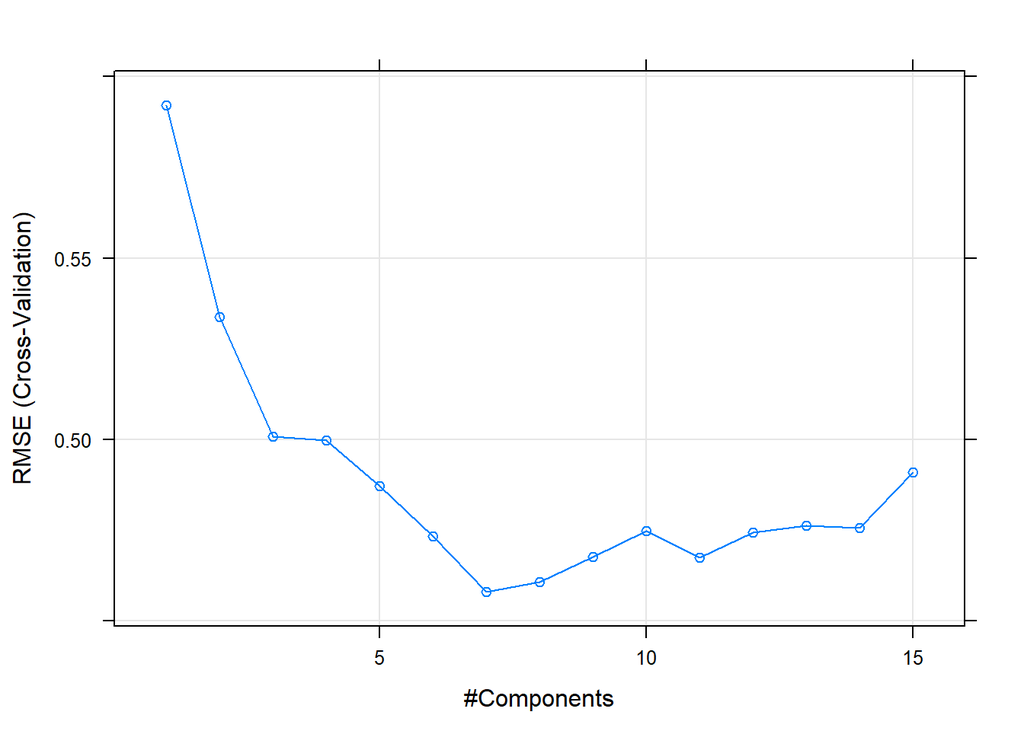

```r
plot(plsTune)
```

```r
summary(plsTune$finalModel)
```

```
## Data:    X dimension: 125 388
##  Y dimension: 125 1
## Fit method: oscorespls
## Number of components considered: 7
## TRAINING: % variance explained
##           1 comps  2 comps  3 comps  4 comps  5 comps  6 comps  7 comps
## X           26.26    40.03    49.00    56.32    63.06    65.79    68.17
## .outcome    26.11    50.77    58.87    65.46    70.39    75.89    79.33
```

**PLS model is 7 is the optimal model. This captures 68.17% of the variation in the predictors and 79.33% of the variation**

#### d) Predict the response for the test set. What is the test set esitmate of $R^2$?

```r
pls.pred <- predict(plsTune, newdata = testFingerprints)
postResample(pred = pls.pred, obs = testPermeability)
```

```
##       RMSE   Rsquared        MAE
## 15.7580242  0.4324274 10.0108477
```

The RMSE is `15.7580242` and $R^2$ of the test set prediction is `0.4324274`

#### e) Try building other models discussed in this chapter. Do any have better predictive performance?

```r
ridgeGrid <- data.frame(lambda = seq(0.02, .35, length = 9))
ridgeTune <- train(trainFingerprints, trainPermeability, method = "ridge",
                   tuneGrid = ridgeGrid,
                   trControl = ctrl,
                   preProc = c("center", "scale"))
ridgeTune
```

```
## Ridge Regression
##
## 125 samples
## 388 predictors
##
## Pre-processing: centered (388), scaled (388)
## Resampling: Cross-Validated (10 fold)
## Summary of sample sizes: 113, 112, 113, 112, 113, 113, ...
## Resampling results across tuning parameters:
##
##   lambda   RMSE      Rsquared   MAE
##   0.02000  12.31918  0.5352243  9.267566
##   0.06125  11.80614  0.5536890  8.866912
##   0.10250  11.76777  0.5563432  8.801663
##   0.14375  11.83743  0.5572497  8.883637
##   0.18500  11.94462  0.5585418  9.002302
##   0.22625  12.09303  0.5593004  9.133174
##   0.26750  12.26041  0.5603573  9.275228
##   0.30875  12.45165  0.5612793  9.456168
##   0.35000  12.66074  0.5620652  9.653745
##
## RMSE was used to select the optimal model using the smallest value.
## The final value used for the model was lambda = 0.1025.
```

```r
ridge.pred <- predict(ridgeTune, newdata = testFingerprints)
postResample(pred = ridge.pred, obs = testPermeability)
```

```
##       RMSE   Rsquared        MAE
## 13.5313372  0.3687824  9.8385404
```

The RMSE is `13.5313372` and $R^2$ of the test set prediction is `0.3687824`

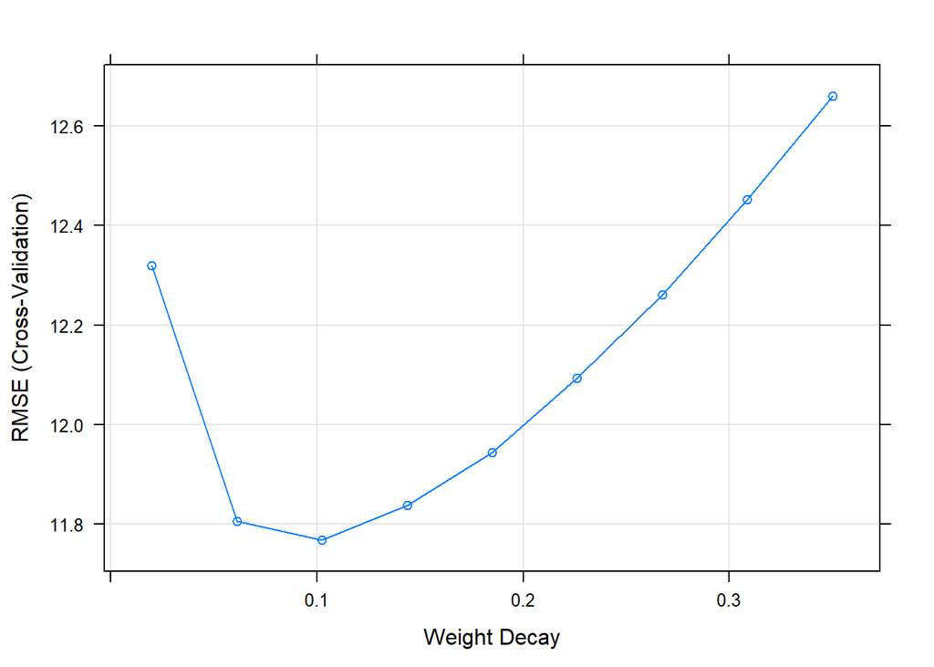

```r
plot(ridgeTune)
```

### 6.3 A chemical manufacturing process for a pharmaceutical product was discussed in Sect.1.4. In this problem, the objective is to understand the relationship between biological measurements of the raw materials (predictors), measurements of the manufacturing process (predictors), and the response of product yield. Biological predictors cannot be changed but can be used to assess the quality of the raw material before processing. On the other hand, manufacturing process predictors can be changed in the manufacturing process. Improving product yield by 1% will boost revenue by approximately one hundred thousand dollars per batch:

#### (a) Start R and use these commands to load the data:

```r
data("ChemicalManufacturingProcess")
dim(ChemicalManufacturingProcess)
```

```
## [1] 176  58
```

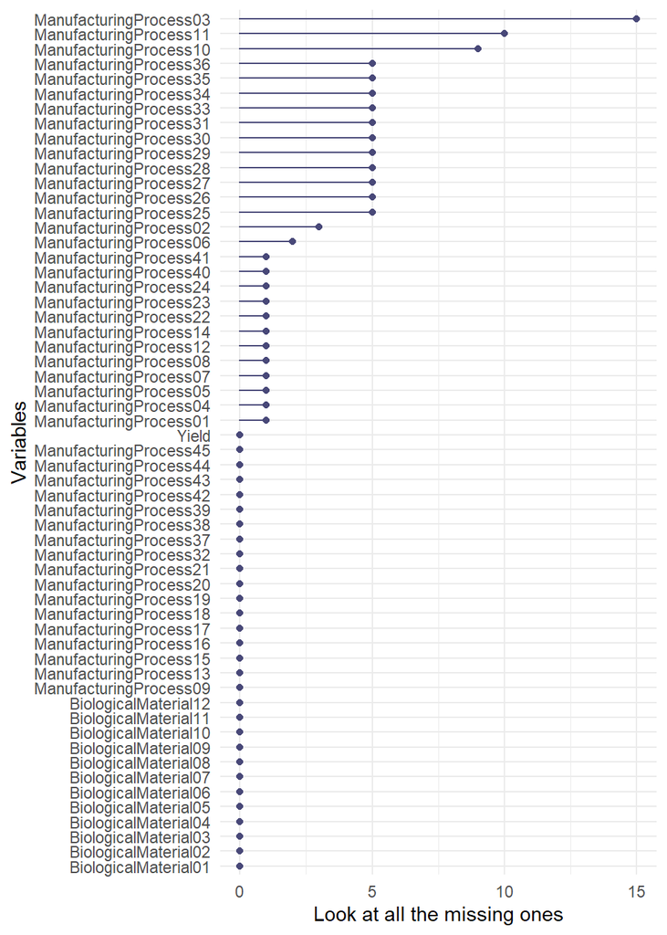

```r
gg_miss_var(ChemicalManufacturingProcess) + labs(y = "Look at all the missing ones")
```

```r
cmp_impute<- missForest(ChemicalManufacturingProcess)
```

```
##   missForest iteration 1 in progress...
```

```
## done!
##   missForest iteration 2 in progress...
```

```
## done!
##   missForest iteration 3 in progress...
```

```
## done!
##   missForest iteration 4 in progress...
```

```
## done!
##   missForest iteration 5 in progress...
```

```
## done!
##   missForest iteration 6 in progress...
```

```
## done!
##   missForest iteration 7 in progress...
```

```
## done!
```

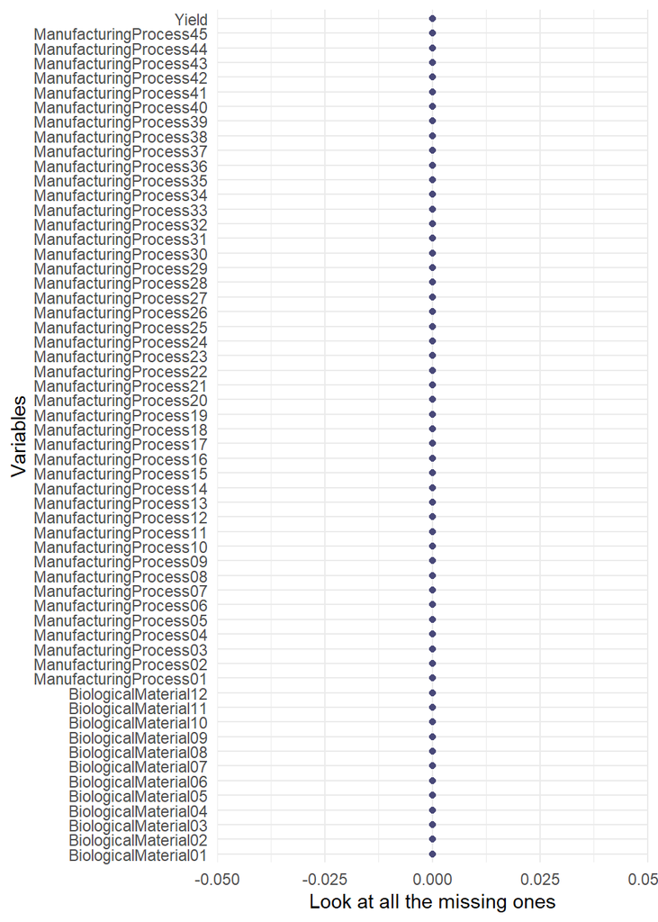

```r
cmp_impute <- as.data.frame(cmp_impute$ximp)

gg_miss_var(cmp_impute, show_pct = TRUE) + labs(y = "Look at all the missing ones")
```

#### c) Split the data into a training and a test set, pre-process the data, and use a model of your choice from this chapter. What is the optimal value of the performance metric?

```r
library(pls)

set.seed(17)

smp1 <- floor(0.75 * nrow(cmp_impute))

trainingRows <- sample(seq_len(nrow(cmp_impute)), size = smp1)
y1 <- sample(seq_len(nrow(cmp_impute)), size = smp1)

cmpTrain <- cmp_impute[trainingRows,-1]
cmpTest <- cmp_impute[-trainingRows,-1]
yTrain <- cmp_impute[y1,1]
yTest <- cmp_impute[-y1,1]

cmpTune <- train(cmpTrain, yTrain,
                 method = "pls",
                 tuneLength = 20, trControl = ctrl,
                 preProc = c("center", "scale"))

cmpTune
```

```
## Partial Least Squares
##
## 132 samples
##  57 predictor
##
## Pre-processing: centered (57), scaled (57)
## Resampling: Cross-Validated (10 fold)
## Summary of sample sizes: 119, 118, 120, 117, 120, 120, ...
## Resampling results across tuning parameters:
##
##   ncomp  RMSE      Rsquared   MAE
##    1     2.086601  0.1231083  1.662202
##    2     2.592784  0.1391767  1.720826
##    3     2.658867  0.1392382  1.755226
##    4     2.449071  0.1594926  1.697227
##    5     2.639974  0.1670721  1.760308
##    6     2.902953  0.1949944  1.826592
##    7     2.842816  0.1697681  1.860282
##    8     2.703167  0.1464872  1.865939
##    9     2.713845  0.1587348  1.856070
##   10     2.908729  0.1406090  1.959426
##   11     3.165194  0.1328351  2.050657
##   12     3.252465  0.1250539  2.071121
##   13     3.433214  0.1234438  2.130068
##   14     3.668955  0.1260363  2.207788
##   15     3.971703  0.1257412  2.302059
##   16     4.184109  0.1344587  2.361407
##   17     4.299645  0.1292648  2.403458
##   18     4.335854  0.1316881  2.412877
##   19     4.525885  0.1368628  2.471902
##   20     4.784033  0.1293965  2.564042
##
## RMSE was used to select the optimal model using the smallest value.
## The final value used for the model was ncomp = 1.
```

#### d) Predict the response for the test set. What is the value of the performance metric and how does this compare with the resampled performance metric on the training set?

```r
cmpPred <- predict(cmpTune, newdata = cmpTest)
postResample(pred = cmpPred, obs = yTest)
```

```
##         RMSE     Rsquared          MAE
## 2.130686e+00 1.583659e-05 1.664855e+00
```

```r
ridgeGrid <- data.frame(.lambda = seq(0, .1, length = 15))
set.seed(17)

ridgeTune2 <- train(cmpTrain, yTrain, method = "ridge",
                      tuneGrid = ridgeGrid,
                      trControl = ctrl)
ridgeTune2
```

```
## Ridge Regression
##
## 132 samples
##  57 predictor
##
## No pre-processing
## Resampling: Cross-Validated (10 fold)
## Summary of sample sizes: 120, 120, 120, 119, 119, 118, ...
## Resampling results across tuning parameters:
##
##   lambda       RMSE       Rsquared   MAE
##   0.000000000  18.930687  0.1506448  6.371037
##   0.007142857   5.565949  0.1503616  2.705400
##   0.014285714   4.476050  0.1573590  2.391740
##   0.021428571   3.958375  0.1625925  2.239005
##   0.028571429   3.646169  0.1665722  2.144118
##   0.035714286   3.435074  0.1696674  2.077669
##   0.042857143   3.282145  0.1721305  2.027880
##   0.050000000   3.166053  0.1741347  1.988835
##   0.057142857   3.074884  0.1758014  1.957554
##   0.064285714   3.001410  0.1772180  1.932097
##   0.071428571   2.940979  0.1784481  1.911618
##   0.078571429   2.890446  0.1795388  1.894298
##   0.085714286   2.847608  0.1805252  1.879272
##   0.092857143   2.810873  0.1814336  1.866090
##   0.100000000   2.779060  0.1822835  1.854418
##
## RMSE was used to select the optimal model using the smallest value.
## The final value used for the model was lambda = 0.1.
```

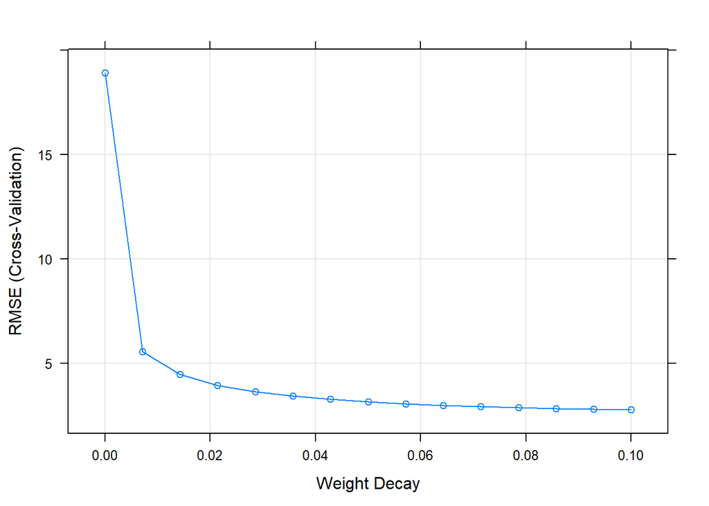

```r
plot(ridgeTune2)
```

```r
ridge.pred <- predict(ridgeTune2, newdata = cmpTest)
postResample(pred = ridge.pred, obs = yTest)
```

```
##       RMSE   Rsquared        MAE
## 2.18188056 0.01650807 1.67904155
```

#### e) Which predictors are most important in the model you have trained? Do either the biological or process predictors dominate the list?

```r
varImp(ridgeTune2)
```

```
## loess r-squared variable importance
##
##   only 20 most important variables shown (out of 57)
##
##                        Overall
## ManufacturingProcess05  100.00
## ManufacturingProcess35   47.34
## ManufacturingProcess02   43.16
## ManufacturingProcess31   37.91
## ManufacturingProcess21   37.91
## ManufacturingProcess06   37.83
## ManufacturingProcess14   33.86
## ManufacturingProcess09   32.66
## ManufacturingProcess10   32.20
## BiologicalMaterial09     29.68
## ManufacturingProcess27   29.66
## BiologicalMaterial11     27.88
## ManufacturingProcess26   27.25
## BiologicalMaterial05     26.43
## BiologicalMaterial03     24.31
## BiologicalMaterial01     23.20
## ManufacturingProcess29   22.43
## ManufacturingProcess39   21.35
## BiologicalMaterial10     21.08
## ManufacturingProcess17   19.04
```

`ManufacturingProcess` seems to have the most importance than `BiologicalMaterial`

#### f) Explore the relationships between each of the top predictors and the response. How could this information be helpful in improving yield in future runs of the manufacturing process?

**the most important manufacturing process steps allows the company to pinpoint where they can start fine tuning the procedure.**